# - notes

layout: post  
title: Notes on Stouffer et al. 2012 Science  
author: Scott  
tags:

- science
- networks
- bipartite

## - notes

### Notes

- title was “Evolutionary conservation of species' roles in food webs”
- used 32 empirical food webs
- questions were:
  - do species have consistent “roles” across different food webs they are embedded in, and
  - are species roles phylogenetically conserved
- Found that
  - species roles (motifs) are conserved across different communities
  - species benefit to the community (they call dynamic importance - bascially is the impact that the motif they are in has on community persistence simulations of the empirical networks) is homogenous - closely related species to have similar benefit to their community than expected at random
  - at larger taxonomic scales, they show that phyla, classes, orders, and families, tend to play similar roles betlween New Zealand food webs, and all other food webs.
- Other questions
  - What are the mechanisms for the evolutionary conservation of species roles?
    - Is it related to similarity in traits?
    - or possibly similarity in abundance?
  - Is there conservation of species roles in mutualistic plant-pollinator networks?
    - this paper only looked at food webs.
- Potential problems
  - they did not provide code, so can't necessarily replicate what they did
  - can we look at where species are in motifs with bipartite networks? that is, species of similar type (plants) can’t interact with one another
    - probably: just means that motifs are of a more limited set, that is, whereas in a food web you can have a triangle, you can only have an open triangle in a bipartite network

[figure not shown]

VS.

[figure not shown]

- Code: asked for code form Daniel Stouffer - it was not provided in the paper

### How can we do something similar with bipartite networks?

- Problems, in bipartite networks:
  - there is no directionality to links, so that decreases the unique graphlets/motifs
- Possible solutions:
  - Use modules? (Olesen *et. al.* 2007) talk about modules as roles in bipartite networks, however this isn't the same as motifs. Motifs/graphlets are asking what roles do species play in sub-structures of the network, whereas with modules we can say whether a species plays the role of a module hub, network hub, connector, or peripheral (according to Olesen terminology). But this isn't the same as motif/graphlets.
  - Converting bipartite two-mode networks to one-mode networks
    - One option is to convert two-mode bipartite networks into one-mode networks, which results in two one-mode networks, one for plants and one for pollinators. Then, each one-mode network represents links shared by species in the same partite. With this, one can look at motifs and graphlets, but what does that mean? If a certain plant species X is found in a lot of motifs of a certain kind, does that tell us anything about the two-mode bipartite network of plant-pollinator interactions?

```r
library(tnet)
library(bipartite)
```

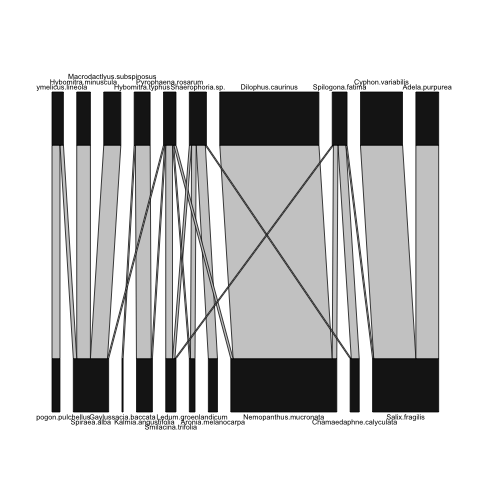

```r
data(small1976)  # load small1976 network (it’s a matrix)
mat <- as.data.frame(small1976)  # convert to data.frame
mat <- mat[, 1:10]  # get samller matrix for ease
plotweb(mat)  # bipartite plot
```

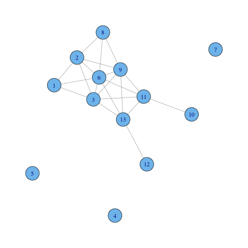

```r
mat_elist <- web2edges(mat, return = T)  # convert to edgelist
mat_onemode <- projecting_tm(mat_elist, method = "Newman")  # make into one-mode network
mat_onemode_i <- tnet_igraph(mat_onemode, directed = F)  # convert to igraph object
plot(mat_onemode_i)  # plot one-mode undirected graph
```

#### Get the .Rmd file used to create this post [at my github account](https://github.com/sckott/scott/blob/master/_drafts/2012-09-20-network-roles.Rmd) - or [.md file](https://github.com/sckott/scott/tree/master/_posts/2012-09-20-network-roles.md).

#### Written in [Markdown](http://daringfireball.net/projects/markdown/), with help from [knitr](http://yihui.name/knitr/), and nice knitr highlighting/etc. in in [RStudio](http://rstudio.org/).

#### References

Olesen JM, Bascompte J, Dupont YL and Jordano P (2007).  
“The Modularity of Pollination Networks.”  
*Proceedings of The National Academy of Sciences*, **104**.  
ISSN 0027-8424, http://dx.doi.org/10.1073/pnas.0706375104.